# Monitoria 8

Sinara

2024-05-03

1. Abrir bases

```r
library(readxl)
base1 <- read_excel("base.xlsx", sheet = "inicio")
base2 <- read_excel("base.xlsx", sheet = "meio")
```

2. Juntar pib com pib defasado

```r
dados <- cbind(base1$pib, base2$pib_d)
colnames(dados) <- c("pib", "pib_d")
```

3. Método Generalizado dos Momentos (GMM)

Permite estimar modelos com base em momentos condicionais (média, variância etc.) e estimar os parâmetros que melhor ajustam esses momentos aos dados.

Dado o modelo: y_t = Beta1x_t + ε_t, x_t representa uma defasagem de y_t ou algum termo exógeno que explica y_t.

Temos que: E(x_tε_t) = 0

```r
library(gmm)
funcao_de_momentos <- function(beta, dados) {
  y <- base1$pib
  x <- base2$pib_d
  moments <- x * (y - beta * x)
  return(cbind(moments))
}

# Estimar o GMM
gmm1 <- gmm(funcao_de_momentos, dados, t0 = 1,  method = "Brent", lower = -10, upper = 10)
summary(gmm1)
```

```
##
## Call:
## gmm(g = funcao_de_momentos, x = dados, t0 = 1, method = "Brent",
##     lower = -10, upper = 10)
##
##
## Method:  twoStep
##
## Kernel:  Quadratic Spectral
##
## Coefficients:
##           Estimate   Std. Error  t value    Pr(>|t|)
## Theta[1]   1.015386   0.012084   84.029547   0.000000
##
## J-Test: degrees of freedom is 0
##                 J-test            P-value
## Test E(g)=0:    668219.263543376  *******
##
## #############
## Information related to the numerical optimization
## Convergence code =  0
## Function eval. =  NA
## Gradian eval. =  NA
```

OBS: O J-test de sobreidentificação é usado para testar a validade dos momentos instrumentais no GMM. A H0 é que os os momentos condicionais dos dados são iguais aos momentos condicionais especificados pelo modelo (momentos instrumentais escolhidos são válidos) . OUTROS TESTES: Wald; Razão da Verossimilhança; Multiplicador de lagrange…

4. Generalização de Hansen (1982) para o GMM

Lida com modelos mais complexos que envolvem dependência temporal e espacial entre as unidades observadas. Tem uma abordagem de duas etapas:

*1ª*: Relaxamento da hipótese E(x_tε_t) = 0. Para isso, é preciso encontrar uma outra variável (zt) que: E(z_tx_t) ≠ 0; e E(z_tε_t) = 0.

Ou seja, um estimador de variáveis instrumentais (IV)

*2ª*: Possibilidade de existir mais de uma variável correlacionada com x_t, porém independente de ε_t. Como haverá duas equações e uma icógnita, usa-se a matriz de covariância de momentos (matriz S) como ponderador - momentos com maior variância devem receber um peso menor.

5. Estimação

Se a estimação da matriz S for consistente, há três métodos principais de estimação por GMM:

*Dois estágios*: 1º impõe-se a matriz identidade; 2º encontram-se os parâmetros do modelo.

*Sequencial*: repetição do método a dois estágios para encontrar os parâmetros do modelo. A iteração se encerra quando há convergência para o critério de convergência.

*Atualização contínua dos parâmetros*: a matriz de covariância é simultaneamente estimada com o vetor de parâmetros

```r
gmm2 <- gmm(funcao_de_momentos, dados, t0 = 1, type = "iterative", method = "Brent", lower = -10, upper = 10)
summary(gmm2)
```

```
##
## Call:
## gmm(g = funcao_de_momentos, x = dados, t0 = 1, type = "iterative",
##     method = "Brent", lower = -10, upper = 10)
##
##
## Method:  iterative
##
## Kernel:  Quadratic Spectral
##
## Coefficients:
##           Estimate   Std. Error  t value    Pr(>|t|)
## Theta[1]   1.015386   0.012084   84.029547   0.000000
##
## J-Test: degrees of freedom is 0
##                 J-test            P-value
## Test E(g)=0:    668219.263543376  *******
##
## #############
## Information related to the numerical optimization
## Convergence code =  0
## Function eval. =  NA
## Gradian eval. =  NA
```

```r
# basta ajustar o parâmetro "type" na função: type=c("twoStep","iterative", "cue")
```

6. Análise da estrutura dos dados

6.1. Autocovariância

Descreve a covariância entre uma série temporal e uma versão atrasada de si mesma. É usada para capturar padrões de dependência temporal nos dados.

Cov(X_t,X_t+k )= E[(X_t−μ)(Xt+k−μ)], onde k é o número de defasagens

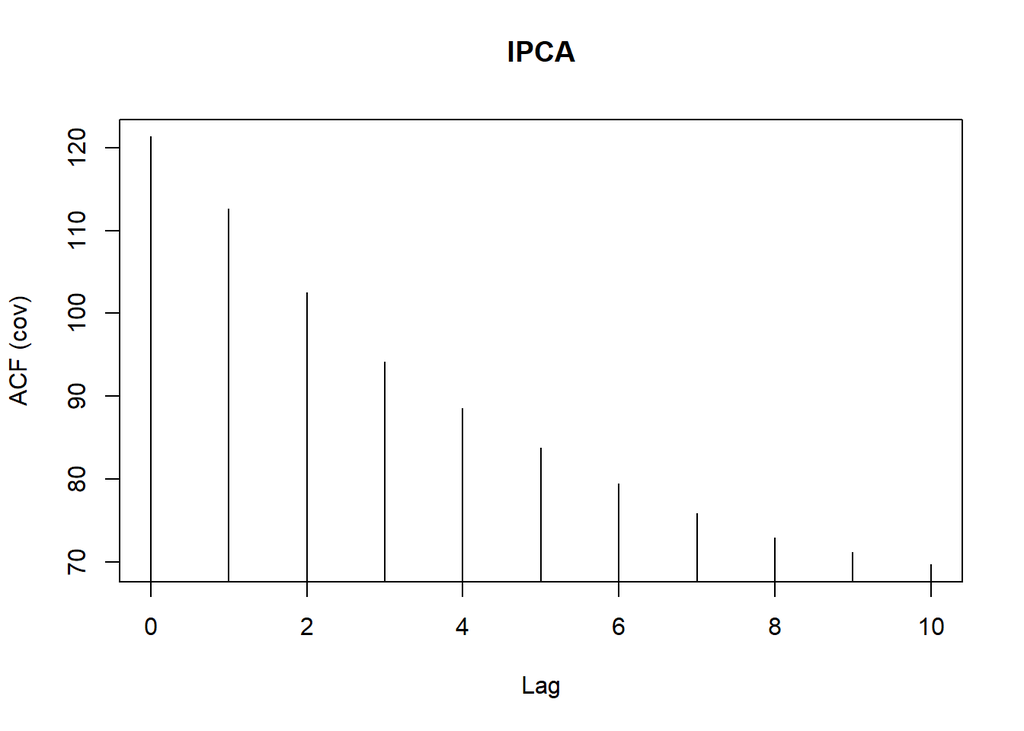

```r
#Abrir dados IPCA - dados mensais de janeiro/2012 a janeiro/2017
base3 <- read_excel("base.xlsx", sheet = "ipca")

autocov <- acf(base3[,1], lag.max = 10, type = "covariance", plot = TRUE)
```

```r
autocov
```

```
##
## Autocovariances of series 'base3[, 1]', by lag
##
##     0     1     2     3     4     5     6     7     8     9    10
## 121.3 112.6 102.6  94.2  88.5  83.7  79.5  75.9  73.0  71.2  69.7
```

6.2. Variância de longo prazo

É uma medida da variabilidade ou dispersão dos valores de uma série temporal ao longo de períodos de tempo mais extensos.

```r
library(robcp)

x <- base3$IPCA

variancia_longo_prazo <- lrv(x, method = "kernel", control = list())
variancia_longo_prazo
```

```
## [1] 726.3142
```

É utilizada para padronizar testes relacionados à média em dados dependentes.

7. Calculando a Matriz de Covariância de Momentos (S)

Descreve as relações de covariância entre os momentos de uma distribuição estatística ou de um conjunto de dados. Existem várias formas de calculá-la, sendo as mais comuns descritas a seguir:

7.1. Newey-West

Estima a matriz S em séries temporais que podem exibir autocorrelação serial, ou seja, leva em consideração a dependência serial nos dados e corrige o viés causado pela autocorrelação.

```r
library(sandwich)

covariancia_longo_prazo_NW <- lrvar(dados, type = "Newey-West")
covariancia_longo_prazo_NW
```

```
##                pib        pib_d
## pib   1.458758e+16 1.443718e+16
## pib_d 1.443718e+16 1.429080e+16
```

7.2. Densidade Espectral

Baseada na análise de frequência dos dados, utiliza a transformada de Fourier ou outras técnicas de análise espectral para calcular a matriz de covariância de momentos em termos de frequência.

```r
covariancia_longo_prazo_AD <- lrvar(dados, type = "Andrews")
covariancia_longo_prazo_AD
```

```
##                pib        pib_d
## pib   1.352819e+16 1.338667e+16
## pib_d 1.338667e+16 1.324964e+16
```

7.3. Branqueamento e coloração

Combina o Newey-West com o estimador espectral e supõe que os momentos têm um alto grau de persistência.

REFERÊNCIAS Rdocumentation. gmm: Generalized method of moment estimation. Disponível em: https://www.rdocumentation.org/packages/gmm/versions/1.8/topics/gmm>. Acesso em: 04 de maio de 2024.

LOST. Generalized Method of Moments. Disponível em: https://lost-stats.github.io/Model_Estimation/GLS/gmm.html. Acesso em 04 de maio de 2024.

TABOGA, Marco. Covariance Matrix. Disponível em: https://www.statlect.com/fundamentals-of-probability/covariance-matrix. Acesso em: 05 de maio de 2024.